# Solución Examen 1. Fundamentos.

# 🤓 🧑‍💻 📖

## 📝 Punto 1:

- Haga el diagrama de Venn con los valores numéricos correspondientes al cardinal de cada región del diagrama.
- Resuelva cada una de las preguntas escribiendo el enunciado de la pregunta y su correspondiente solución.

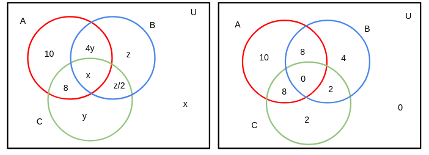

```python
from IPython.display import Image
Image("Punto1D1.png")
```

🧐 Sistemas de ecuaciones 1:

$$26=18+4y+x,$$$$14=\frac{3}{2}z+x+4y,$$$$34=18+5y+2x+\frac{3}{2}z.$$

Con solución $y=2$, $x=0$, $z=4$. Y corres ponde a las situaciones problema:

- Escuela de baile,
  - 34
  - 0
  - 18
- Departamentos.
  - 34
  - 0
  - 18

🧐 Sistemas de ecuaciones 2:

$$26=18+4y+x,$$$$12=\frac{z}{2}+8+x+y,$$$$18=8+4y+\frac{z}{2}.$$

Con solución $y=2$, $x=0$, $z=4$. Y corres ponde a las situaciones problema:

- Actividades extracurriculares,
  - 16
  - 8
  - 0
- Juagos de mesa.
  - 16
  - 8
  - 0

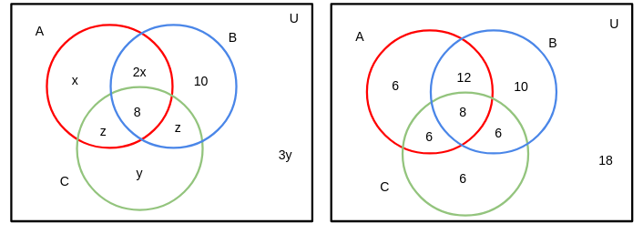

```python
from IPython.display import Image
Image("Punto1D2.png")
```

🧐 Sistemas de ecuaciones 1:

$$32=3x+8+z,$$$$36=18+2x+z,$$$$26=2z+y+8.$$

Con solución $x=y=z=6$. Y corres ponde a las situaciones problema:

- Libros del año,
  - 54
  - 20
  - 46
- Sabores de helado.
  - 22
  - 8
  - 18

🧐 Sistema de ecuaciones 2:

- Emisora de radio:
  - 72
  - 20
  - 6
- La ecuación más relevante:
  - 48
  - 14
  - 18

## 📝 Punto 2:

Resuelva:

1. De los siguientes conjuntos elija el que tiene cardinal cuatro y escribalo por extensión:
- $A_1=\{n\in\mathbb{Z}^+: n \text{ es un cuadrado perfecto menos que 25}\}$

```python
A_1=set([1,4,9,16])
print(A_1)
type(A_1)
```

```
{16, 1, 4, 9}
```

```
<class 'set'>
```

- $A_2=\{x_{i+1}=x_i +1: i=0,1,2,3. \text{ y } x_0=1\}$

```python
A_2=set([2,3,4,5])
print(A_2)
```

```
{2, 3, 4, 5}
```

- $A_3=\{x\in \mathbb{Z}: (x^2+x-6)(x^2-x-6)=0\}$

```python
A_3=set([-3,-2,2,3])
print(A_3)
```

```
{2, 3, -3, -2}
```

- $A_4=\{x\in \mathbb{N}:2\leq x\leq 13 \text{ y } x\%3=1\}$

```python
A_4=set([4,7,10,13])
print(A_4)
```

```
{10, 4, 13, 7}
```

1. Del conjunto anterior calcule el conjunto de partes (excriba sus elementos por extensión) y determine su cardinal.

```python
PA_1=set(Subsets(A_1))
print("Conjunto de partes: ", PA_1)
print()
print("Cardinal del conjunto de partes: ", len(PA_1))
```

```
Conjunto de partes:  {{16, 9}, {1, 4}, {1, 9}, {1, 4, 9}, {9}, {16, 4}, {16, 1, 4}, {16, 1, 4, 9}, {1}, {9, 4}, {16, 1, 9}, {16, 1}, {}, {16, 9, 4}, {16}, {4}}

Cardinal del conjunto de partes:  16
```

```python
PA_2=set(Subsets(A_2))
print("Conjunto de partes: ", PA_2)
print()
print("Cardinal del conjunto de partes: ", len(PA_2))
```

```
Conjunto de partes:  {{3, 4}, {2}, {2, 3, 4}, {2, 3}, {4, 5}, {2, 4, 5}, {2, 5}, {2, 3, 4, 5}, {3}, {2, 4}, {2, 3, 5}, {3, 5}, {3, 4, 5}, {}, {4}, {5}}

Cardinal del conjunto de partes:  16
```

```python
PA_3=set(Subsets(A_3))
print("Conjunto de partes: ", PA_3)
print()
print("Cardinal del conjunto de partes: ", len(PA_3))
```

```
Conjunto de partes:  {{3, -3, -2}, {2}, {2, 3, -3}, {2, 3}, {3, -3}, {3, -2}, {-3}, {2, 3, -2}, {2, 3, -3, -2}, {-3, -2}, {-2}, {3}, {2, -3, -2}, {}, {2, -2}, {2, -3}}

Cardinal del conjunto de partes:  16
```

```python
PA_4=set(Subsets(A_4))
print("Conjunto de partes: ", PA_4)
print()
print("Cardinal del conjunto de partes: ", len(PA_4))
```

```
Conjunto de partes:  {{10, 4}, {13, 7}, {10, 7}, {4, 13}, {10, 4, 7}, {4, 13, 7}, {10, 4, 13}, {10, 13}, {7}, {10}, {10, 4, 13, 7}, {13}, {}, {10, 13, 7}, {4}, {4, 7}}

Cardinal del conjunto de partes:  16
```

## 📝 Punto 3:

Consideremos el siguiente conjunto X = {a, b, c, d}. Defina una relación tal que cumpla las siguientes propiedades:

```python
#Producto cartesiano de X con X
X=['a','b','c','d']
CX=[(i,j) for i in X for j in X]
print(set(CX))
```

```
{('a', 'c'), ('b', 'd'), ('b', 'a'), ('b', 'b'), ('c', 'b'), ('c', 'c'), ('c', 'd'), ('d', 'a'), ('a', 'a'), ('d', 'b'), ('d', 'd'), ('c', 'a'), ('d', 'c'), ('a', 'b'), ('a', 'd'), ('b', 'c')}
```

1. Reflexiva, simétrica y no transitiva

```python
R=[(i,j) for i in X for j in X if i==j]
R.append((X[0],X[2]))
R.append((X[2],X[0]))
R.append((X[2],X[3]))
R.append((X[3],X[2]))
print(set(R))
```

```
{('a', 'c'), ('c', 'd'), ('b', 'b'), ('a', 'a'), ('d', 'd'), ('c', 'a'), ('d', 'c'), ('c', 'c')}
```

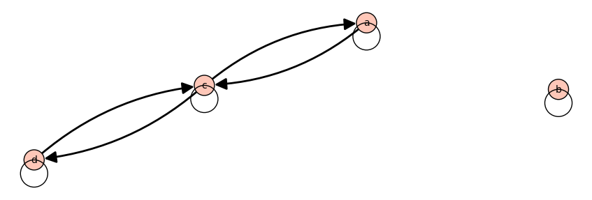

```python
g=DiGraph(loops=True)
g.add_vertices(X)
g.add_edges(R)
g.show(figsize=[10,3])
```

1. Reflexiva, no simétrica y no transitiva

```python
#X=['a','b','c','d']
R_2=[(i,j) for i in X for j in X if i==j]
R_2.append((X[2],X[0]))
R_2.append((X[2],X[1]))
R_2.append((X[1],X[3]))
print(set(R_2))
```

```
{('b', 'b'), ('a', 'a'), ('d', 'd'), ('c', 'a'), ('b', 'd'), ('c', 'c'), ('c', 'b')}
```

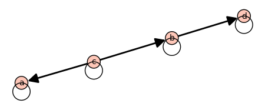

```python
g_2=DiGraph(loops=True)
g_2.add_vertices(X)
g_2.add_edges(R_2)
g_2.show(figsize=[10,2])
```

1. Reflexiva, antisimétrica y no transitiva

```python
#X=['a','b','c','d']
R_3=[(i,j) for i in X for j in X if i==j]
R_3.append((X[0],X[1]))
R_3.append((X[1],X[2]))
R_3.append((X[2],X[3]))
R_3.append((X[3],X[0]))
print(set(R_3))
```

```
{('c', 'd'), ('d', 'a'), ('b', 'b'), ('a', 'a'), ('d', 'd'), ('a', 'b'), ('c', 'c'), ('b', 'c')}
```

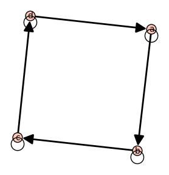

```python
g_3=DiGraph(loops=True)
g_3.add_vertices(X)
g_3.add_edges(R_3)
g_3.show(figsize=[10,3])
```

1. No reflexiva, simétrica y transitiva.

```python
#X=['a','b','c','d']
X_aux=['a','b','c']
R_4=[(i,j) for i in X_aux for j in X_aux]
print(set(R_4))
```

```
{('a', 'c'), ('c', 'c'), ('b', 'a'), ('c', 'b'), ('a', 'a'), ('c', 'a'), ('a', 'b'), ('b', 'b'), ('b', 'c')}
```

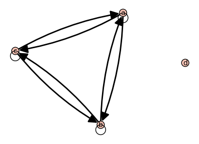

```python
g_4=DiGraph(loops=True)
g_4.add_vertices(X)
g_4.add_edges(R_4)
g_4.show(figsize=[10,3])
```

1. No es reflexiva, no es simétrica y tranitiva.

```python
#X=['a','b','c','d']
R_5=[]
R_5.append((X[2],X[1]))
R_5.append((X[1],X[3]))
R_5.append((X[2],X[3]))
print(set(R_5))
```

```
{('c', 'd'), ('b', 'd'), ('c', 'b')}
```

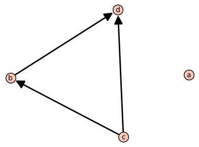

```python
g_5=DiGraph(loops=True)
g_5.add_vertices(X)
g_5.add_edges(R_5)
g_5.show(figsize=[10,3])
```

## 📝 Punto 4:

Considere el conjunto construı́do en el punto 2 parte a, tome una partición del mismo y determine una relación de equivalencia sobre dicho conjunto.

- $A_1=\{16, 1, 4, 9\}$

```python
#Convertí de set a list
PA_1=[a for a in PA_1]
print(PA_1)
# Seleccionar dado un elemento todos los conjuntos disjuntos a el
a=PA_1[4]
print()
print("Elemento: ", a)
Ca=[b  for b in PA_1 if a.intersection(b)==set([])]
Ca
```

```
[{16, 9}, {1, 4}, {1, 9}, {1, 4, 9}, {9}, {16, 4}, {16, 1, 4}, {16, 1, 4, 9}, {1}, {9, 4}, {16, 1, 9}, {16, 1}, {}, {16, 9, 4}, {16}, {4}]

Elemento:  {9}
```

```
[{1, 4}, {16, 4}, {16, 1, 4}, {1}, {16, 1}, {}, {16}, {4}]
```

```python
b=Ca[4]
print("Elemento: ", b)
Ca=[c  for c in Ca if b. intersection(c)==set([])]
Ca
```

```
Elemento:  {16, 1}
```

```
[{}, {4}]
```

```python
Pr=[a,b,Ca[1]]
Pr
```

```
[{9}, {16, 1}, {4}]
```

```python
R=[]
for i in Pr:
    for j in i:
        for k in i:
            R.append((j,k))
set(R)
```

```
{(1, 1), (1, 16), (4, 4), (9, 9), (16, 1), (16, 16)}
```

Por el teorema visto en clase, como $R=\{(1, 1), (1, 16), (4, 4), (9, 9), (16, 1), (16, 16)\}$ es una relación que viene de una partición $X/R=\{\{9\}, \{16, 1\}, \{4\}\}$, entonces $R$ es relación de euivalencia sobre $X$.

- $A_2=\{2, 3, 4, 5\}$

```python
print("Conjunto:", A_2)
print()
print("Conjunto de partes:", set(PA_2))
```

```
Conjunto: {2, 3, 4, 5}

Conjunto de partes: {{2, 3, 4}, {2, 3}, {4, 5}, {2, 3, 4, 5}, {5}, {4}, {3, 4}, {2}, {2, 4, 5}, {2, 5}, {3}, {2, 4}, {2, 3, 5}, {3, 5}, {3, 4, 5}, {}}
```

```python
Pr=[{2, 3},{4, 5}]
print("Partición: ",Pr)
print()
R=[]
for i in Pr:
    for j in i:
        for k in i:
            R.append((j,k))
print("Relación de equivalencia: ",set(R))
```

```
Partición:  [{2, 3}, {4, 5}]

Relación de equivalencia:  {(3, 2), (5, 4), (3, 3), (5, 5), (4, 5), (4, 4), (2, 3), (2, 2)}
```

- $A_3=\{{2, 3, -3, -2}\}$

```python
print("Conjunto:", A_3)
print()
print("Conjunto de partes:", set(PA_3))
```

```
Conjunto: {2, 3, -3, -2}

Conjunto de partes: {{3, -3, -2}, {2, 3, -3}, {2, 3}, {3, -2}, {2, 3, -2}, {2, -3, -2}, {2, -2}, {2}, {3, -3}, {-3}, {2, 3, -3, -2}, {-3, -2}, {-2}, {3}, {}, {2, -3}}
```

```python
Pr=[{2},{3},{-2},{-3}]
print("Partición: ",Pr)
print()
R=[]
for i in Pr:
    for j in i:
        for k in i:
            R.append((j,k))
print("Relación de equivalencia: ",set(R))
```

```
Partición:  [{2}, {3}, {-2}, {-3}]

Relación de equivalencia:  {(-2, -2), (-3, -3), (3, 3), (2, 2)}
```

- $A_4=\{10, 4, 13, 7\}$

```python
print("Conjunto:", A_4)
print()
print("Conjunto de partes:", set(PA_4))
```

```
Conjunto: {10, 4, 13, 7}

Conjunto de partes: {{10, 4}, {10, 4, 13}, {10, 13}, {10}, {4}, {13, 7}, {10, 7}, {4, 13}, {10, 4, 7}, {4, 13, 7}, {4, 7}, {7}, {10, 4, 13, 7}, {13}, {}, {10, 13, 7}}
```

```python
Pr=[A_4]
print("Partición: ",Pr)
print()
R=[]
for i in Pr:
    for j in i:
        for k in i:
            R.append((j,k))
print("Relación de equivalencia: ",set(R))
```

```
Partición:  [{10, 4, 13, 7}]

Relación de equivalencia:  {(4, 10), (4, 7), (10, 4), (13, 13), (10, 10), (10, 7), (10, 13), (4, 4), (13, 4), (7, 13), (7, 7), (4, 13), (7, 4), (13, 7), (7, 10), (13, 10)}
```